# Udacity Data Analyst NanoDegree Project 2

## The Titanic Survivors, what passenger demographics tell us

In this project I will delve in to the [Titanic Passenger demographics](https://www.kaggle.com/c/titanic/data) as provided by Kaggle.com. I will be investigating the relationships between passenger survival and various demographic variables in an attempt to draw a tentative conclusion on whether said demographic variables affected the chances of surival in the Titanic tragedy.

First import the necessary modules, and read the relevant data into a Pandas dataframe. I am dropping columns that I dont find relevant to my study, and renaming Sex category to Gender to ensure a G rating for our younger viewers.

```python
import matplotlib.pyplot as plt
from matplotlib import style
import numpy as np
import pandas as pd
style.use('ggplot')

df = pd.read_csv('titanic-data.csv')
df.drop((['PassengerId', 'Ticket', 'Fare', 'Cabin', 'Embarked']), axis=1, inplace=True)
df.rename(columns={'Sex':'Gender'}, inplace=True)
```

Add any functions here to reduce duplicated code:

```python
def survival_pct(category):
    percent = '{:.2f}'.format((category)*100)
    return percent
```

## Wrangle the Data!

Check for null entries, and for possible duplicate rows.

```python
print("The DataFrame info is:")
df.info()
print("")
print("Categories with NULL data:")
print(df.isnull().sum())
print("")
print('There are {} duplicate rows'.format(df.duplicated().sum()))
```

```
The DataFrame info is:
<class 'pandas.core.frame.DataFrame'>
RangeIndex: 891 entries, 0 to 890
Data columns (total 7 columns):
Survived    891 non-null int64
Pclass      891 non-null int64
Name        891 non-null object
Gender      891 non-null object
Age         714 non-null float64
SibSp       891 non-null int64
Parch       891 non-null int64
dtypes: float64(1), int64(4), object(2)
memory usage: 48.8+ KB

Categories with NULL data:
Survived      0
Pclass        0
Name          0
Gender        0
Age         177
SibSp         0
Parch         0
dtype: int64

There are 0 duplicate rows
```

From the results of df.info(), we can see that the number of entries for Age is less than the number of entries for all other fields. Further, we can see that Age has 177 null entries. We will proceed with 2 dataframes, 1 with all entries for Age, including null values, and 1 with null Age entries removed so that null entries do not skew Age based results. Also creating a new DataFrame column for 'Child (1)' or 'Adult (0)', assuming that in that era a person 16 or older would likely be considered an adult.

```python
df['Child'] = (df['Age'] < 16).astype(int)
ignored_age = df['Age'].isnull().sum()
ignored_age_pct = float(ignored_age)/(len(df.index))
df_age = df.dropna()
df_age.info()
df_age.isnull().sum()
```

```
<class 'pandas.core.frame.DataFrame'>
Int64Index: 714 entries, 0 to 890
Data columns (total 8 columns):
Survived    714 non-null int64
Pclass      714 non-null int64
Name        714 non-null object
Gender      714 non-null object
Age         714 non-null float64
SibSp       714 non-null int64
Parch       714 non-null int64
Child       714 non-null int64
dtypes: float64(1), int64(5), object(2)
memory usage: 50.2+ KB
```

```
Survived    0
Pclass      0
Name        0
Gender      0
Age         0
SibSp       0
Parch       0
Child       0
dtype: int64
```

**Get some High Level statistics on the passengers.**

```
The Total Passengers with demographic data was 891.
The Total Surviving Passenger count was 342.
The Percentage of Survivors was 38.38%.
The Percentage of passengers ignored due to missing age data is 19.87%.

The male and female counts are:
male      577
female    314
Name: Gender, dtype: int64
```

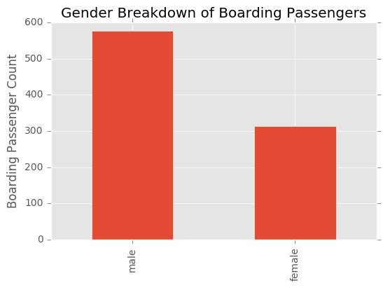

```
The child(1) and adult(0) counts are:
0    808
1     83
Name: Child, dtype: int64
```

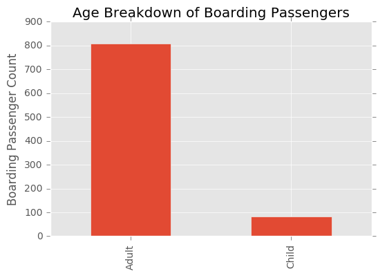

```python
print('The Total Passengers with demographic data was {}.'.format(len(df.index)))
print('The Total Surviving Passenger count was {}.'.format((df['Survived']).sum()))
survivor_percentage= df['Survived'].mean()
print('The Percentage of Survivors was {}%.'.format(survival_pct(survivor_percentage)))
print('The Percentage of passengers ignored due to missing age data is {}%.'.format(survival_pct(ignored_age_pct)))
print("")

print('The male and female counts are:')
gender = df['Gender'].value_counts()
print(gender)
gender.plot.bar()
plt.ylabel('Boarding Passenger Count')
plt.title('Gender Breakdown of Boarding Passengers')
plt.show()

print('The child(1) and adult(0) counts are:')
child = df['Child'].value_counts()
print(child)
child.plot.bar()
plt.ylabel('Boarding Passenger Count')
plt.title('Age Breakdown of Boarding Passengers')
plt.xticks([0, 1], ['Adult', 'Child'])
plt.show()
```

## Explore the Data!

Questions of Interest:  
1- Did the Socio-economic status (SES) affect the survival rate?  
2- Did age affect the survival rate?  
3- Did 'women and children first' play out as expected?

**1- Did the Socio-economic status (SES) affect the survival rate?**  
We will assume that the passenger class (Pclass) is representative of the SES of the passenger:  
Pclass 1 -> high SES  
Pclass 2 -> mid SES  
Pclass 3 -> low SES

```
The First Class Survival Rate was 62.96%.
The Second Class Survival Rate was 47.28%.
The Third Class Survival Rate was 24.24%.
```

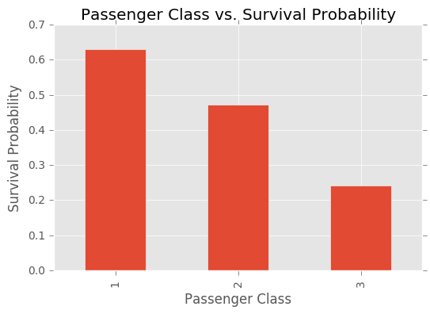

```python
survivors_by_class = df.groupby('Pclass')['Survived'].mean()

print('The First Class Survival Rate was {}%.'.format(survival_pct(survivors_by_class[1])))
print('The Second Class Survival Rate was {}%.'.format(survival_pct(survivors_by_class[2])))
print('The Third Class Survival Rate was {}%.'.format(survival_pct(survivors_by_class[3])))

survivors_by_class.plot.bar()

plt.xlabel('Passenger Class')
plt.ylabel('Survival Probability')
plt.title('Passenger Class vs. Survival Probability')
plt.show()
```

It is clear from the calculated survival rate percentages, and the graphical visualization that the passenger class, and thus the assumed SES did have a significant impact on the chances of survival, with those in higher status having a greater chance of survival. From the data it is unclear how the SES impact is manifested. It is safe to assume that the higher the passenger class, the closer the cabins are to the upper decks, and thus to the lifeboats. It is possible that a passenger of higher SES, even if located in a lower passenger class cabin could have been given preferential treatment in evacuation by their fellow passengers. Again, we do not have the proper data to substantiate these hypothesis.

**2- Did age have an affect on survival rate?**  
Will use df_age DataFrame with Nan removed.  
Will seperate children (< 16yrs) from adults (>= 16yrs).

```
The Total Boarding Passengers with Age data was 714.
The Total Surviving Passenger count with Age data was 290.
The Percentage of Adults aged 16 and over that survived was 38.19%.
The Percentage of Children aged 15 and under that survived was 59.04%.
```

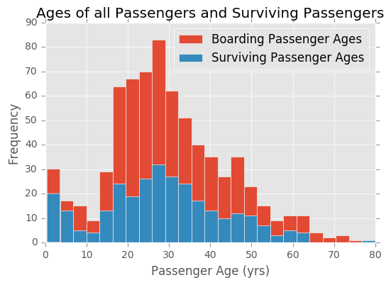

```python
print('The Total Boarding Passengers with Age data was {}.'.format(len(df_age.index)))
print('The Total Surviving Passenger count with Age data was {}.'.format((df_age['Survived']).sum()))

survivors_by_age = df_age.groupby('Child')['Survived'].mean()

print('The Percentage of Adults aged 16 and over that survived was {}%.'.format(survival_pct(survivors_by_age[0])))
print('The Percentage of Children aged 15 and under that survived was {}%.'.format(survival_pct(survivors_by_age[1])))


plt.xlabel('Passenger Age (yrs)')
plt.title('Ages of all Passengers and Surviving Passengers')
df_age['Age'].plot.hist(bins=25, label = 'Boarding Passenger Ages')
df_age_surv = df_age[(df_age['Survived'] == 1)]
df_age_surv['Age'].plot.hist(bins=25, label = 'Surviving Passenger Ages')
plt.legend()
plt.show()
```

**3- Did 'women and children first' apply?**

```
Gender  Child
female  0        0.775229
        1        0.651163
male    0        0.174334
        1        0.525000
Name: Survived, dtype: float64
```

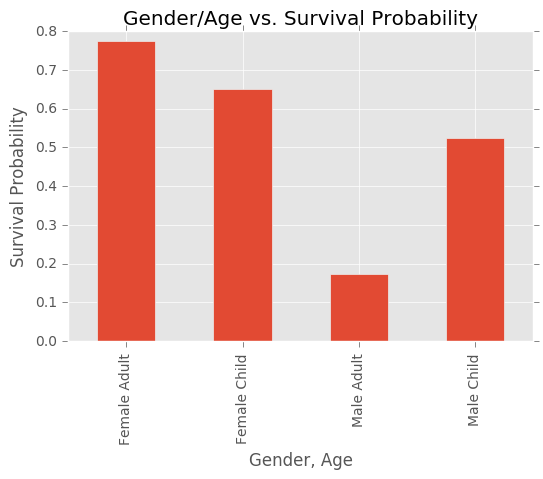

```python
survivors_by_gender_and_age = df_age.groupby((['Gender', 'Child']),as_index=True)['Survived'].mean()

print(survivors_by_gender_and_age)

survivors_by_gender_and_age.plot.bar()
plt.xlabel('Gender, Age')
plt.ylabel('Survival Probability')
plt.title('Gender/Age vs. Survival Probability')
plt.xticks([0, 1, 2, 3], ['Female Adult', 'Female Child', 'Male Adult', 'Male Child'])
plt.show()
```

Again, from the survival percentages calculated above, we can see that being a female and/or a child did appear to have an affect on survival probability. Being an adult male on board the Titanic led to a dismal outcome for most of them. Chivalry aboard the Titanic was not dead! Although most of the chivalrous did end up dying in the tragedy.

## Conclusion:

Due to the limited and incomplete data set provided for this analysis, and without performing statistical analysis on the given sample, the answers to our data exploration questions cannot be determined with any degree of confidence, nor can we claim that any of the correlations we found to be the cause or survival.  
The data set provided was a sample of the population of passengers on board the Titanic. We have no idea what the demographics of the missing passengers were, they could have all been children that died, or men that lived. Both of these hypothetical cases would have changed our results significantly.  
There was missing age demographical data in the data set provided. I chose to remove the passengers with missing age data from any analysis that used age as one of the independant variables. By remove these passenger records, we are ignoring close to 20% of the sample data. This severly limits the accuracy of our conclusions. Another solution to dealing with the passenger records with missing age demographics would have been to fill in the missing data with values, such as the mean or median age of our sample. This solution would still have severly limited the accuracy of our conclusions.  
Given the above limitations, and recognizing that we are not performing any statistical analysis in this study, it is my hope that the reader should feel that in the case of the Titanic Tragedy, and out of respect for the many that perished, that chivalry was not dead.

### Resources:

https://www.datacamp.com/community/blog/python-pandas-cheat-sheet#gs.puUo6b0

https://pythonprogramming.net

http://stackoverflow.com